# Project 1:Investigating Important Factors of U.S. Colleges and Universities

Allison McNairy, Shuhan Shen, Thao Nguyen

October 30, 2022

```r
library(tidyverse)
library(rvest)
library(knitr)
```

# 1. Introduction

Our project goal is to investigate the various factors incoming college students may research when deciding when choosing a university they want to attend. However, our study primarily focuses on the top ranked 100 universities in the U.S.

We collected data of the top 104 universities in 2018 from baike.baidu.com which contains data of college names imported from US News. After further manipulation we create 5 variables: *college ranking, college name, tuition, enrollment, and whether they were a private or public university*. We then combined this dataset with two online sources from Kaggle.com and opendatasoft.com. Combining this information gives us a finalized dataset that contains variables of *college ranking, college name, tuition, enrollment, private or public university, and location variables of state and region*. We then looked for new databases with other features and found another Kaggle.com source, which contains college variables similar to the ones previously listed, but also includes *salary information, population of STEM students, and male-female students ratios*. Our finalized dataset contains 104 observations and 12 variables, which we used to conduct analytical investigations on the variables of **college name and ranking, enrollment, tuition, school type (public/private) graduation rate, region, salary and diversity**.

Furthermore, our goal is to analyze variables that impact university selection choice based on the following three groups: academic quality, costs, and location. We plan to investigate these groups by asking the following questions:

1. Academic Quality
1. What is the relationship between university ranking and if the school is private or public?
2. Do higher ranking schools have a larger student population than lower ranking ones? Is the correlation different between private and public schools?
3. Do schools with overall higher rankings have a larger population of STEM students?
4. Are initial salaries and mid-career salaries for recent graduates higher on average if the student graduated from a high ranking school?
2. Location & Diversity
1. What region has the highest number of top ranked schools?
2. Which regions tend to have more diverse student bodies?
3. Costs
1. How affordable are high ranking universities?
2. What is the average cost for the top ranked universities?
3. What is the average cost of tuition for each region?

Asking these questions segways into our statistical investigation. We hypothesize that private universities on average will have higher rankings and better quality, more expensive tuition, and most likely be concentrated in the Northeast region of the U.S. We also expect to see public universities with relatively cheaper tuition rates compared to private universities, but also a range of good and poor rankings. We chose to investigate U.S. colleges and universities because as college students ourselves, we understand that there are many factors that impact an incoming student’s decision on where to attend for higher education. We hope that our findings can provide insight and may even aid in someone’s college decision in the future.

# 2. Methodology

### 2.1 Initializing our table

The table we are using imported data from US NEWS Top 100 Schools webpage, which we obtained from ‘https://baike.baidu.com/item/美国大学综合排名/17602737?fr=aladdin’ to form our initial table. The variables we look at are *college ranking, college name, tuition, and enrollment*. The key feature of this table is college name (NAME), which we will use to join other datasets.

```r
source1 <- paste0("https://baike.baidu.com/item/美国大学综合排名/17602737?fr=aladdin")
source1_html <- read_html(source1)
source1_tables <- source1_html %>% html_nodes("table")
source1_raw_data <- source1_tables[[3]] %>% html_table() ## find the third table in the website page
names(source1_raw_data) <- c("Ranking","Chinese_Names","NAME","Tuition","Enrollment")
source1_raw_data<-source1_raw_data[-1,]
source1_raw_data<-source1_raw_data[,-2] # delete unnessary rows and columns
source1_raw_data
```

```
## # A tibble: 103 × 4
##    Ranking NAME                                  Tuition Enrollment
##    <chr>   <chr>                                 <chr>   <chr>
##  1 1       Princeton University                  47140   5400
##  2 2       Harvard University                    48949   6710
##  3 3       University of Chicago                 54825   5941
##  4 3       Yale University                       51400   5472
##  5 5       Columbia University                   57208   6113
##  6 5       Massachusetts Institute of Technology 49892   4524
##  7 5       Stanford University                   49617   7034
##  8 8       University of Pennsylvania            53534   10019
##  9 9       Duke University                       53744   6609
## 10 10      California Institute of Technology    49908   979
## # … with 93 more rows
```

### 2.2 Add Tuition Column

In the tuition column, some schools have both in-state and out-of-state tuition, because it is a public university. We use `separate()` to split the Tuition column into two separate columns, one being out-of-state tuition and the other in-state tuition (if any). Another variable we created was a Public/Private column which will help with analyzing tuition data. We also further cleaned the tuition column by eliminating `$` and `,` .

```r
# delete in_state tuition
source1_tuition_fix <-source1_raw_data %>% separate('Tuition', c("Tuition", "out_of_state"),sep = "（out-of-state），")
# add a new column: private/public school based on tuition column
for(i in 1:103){
  if(is.na(source1_tuition_fix$out_of_state[i])){
    source1_tuition_fix$out_of_state[i] = "Private"
  } else{
    source1_tuition_fix$out_of_state[i] = "Public"
  }
}
names(source1_tuition_fix) <- c("Ranking","NAME","Tuition","Public/Private","Enrollment")

# data cleaning for tuition column
for(i in 1:103){
  source1_tuition_fix$NAME[i]=toupper(source1_tuition_fix$NAME[i])
  source1_tuition_fix$NAME[i]=source1_tuition_fix$NAME[i] %>% str_replace("--", "-")
  source1_tuition_fix$Tuition[i]=gsub('[,]','',source1_tuition_fix$Tuition[i])
  source1_tuition_fix$Tuition[i]=gsub('[$]','',source1_tuition_fix$Tuition[i])
}
source1_tuition_fix
```

```
## # A tibble: 103 × 5
##    Ranking NAME                                  Tuition Public/Privat…¹ Enrol…²
##    <chr>   <chr>                                 <chr>   <chr>           <chr>
##  1 1       PRINCETON UNIVERSITY                  47140   Private         5400
##  2 2       HARVARD UNIVERSITY                    48949   Private         6710
##  3 3       UNIVERSITY OF CHICAGO                 54825   Private         5941
##  4 3       YALE UNIVERSITY                       51400   Private         5472
##  5 5       COLUMBIA UNIVERSITY                   57208   Private         6113
##  6 5       MASSACHUSETTS INSTITUTE OF TECHNOLOGY 49892   Private         4524
##  7 5       STANFORD UNIVERSITY                   49617   Private         7034
##  8 8       UNIVERSITY OF PENNSYLVANIA            53534   Private         10019
##  9 9       DUKE UNIVERSITY                       53744   Private         6609
## 10 10      CALIFORNIA INSTITUTE OF TECHNOLOGY    49908   Private         979
## # … with 93 more rows, and abbreviated variable names ¹`Public/Private`,
## #   ²Enrollment
```

### 2.3 Add State Column

By using `left_join`, we combined our existing table by the college name variable with a college_to_state table that contains state information. Since the names are different in forms between the tables, we used`toupper()`and `str-replace()` to match the names. However, there are still some unmatched college names. To fix this we manually filled out the missing state information for some colleges.

‘source2_college_to_state_table’ database source URL:‘https://public.opendatasoft.com/explore/dataset/us-colleges-and-universities/table/’

```r
source2_college_to_state_table <- read.csv(file = '/Users/nguyenthao/Documents/Fall22/SDS322E/Project1/college_to_state.csv')
main_add_state <- source1_tuition_fix %>% left_join(source2_college_to_state_table, by = "NAME")
main_add_state<-main_add_state[,-c(6:11)]
main_add_state <- main_add_state[,c(1:6)]
#manually input unmatached state
main_add_state$STATE[which(is.na(main_add_state$STATE))] <-c('NY','MO','VA','NC','VA','GA','LA','PA','IL','OH','IN','TX','WA','PA','TX','VA','MI','NC','NY','IN','CO','NY','NY','OK')
main_add_state
```

```
## # A tibble: 103 × 6
##    Ranking NAME                                  Tuition Public/…¹ Enrol…² STATE
##    <chr>   <chr>                                 <chr>   <chr>     <chr>   <chr>
##  1 1       PRINCETON UNIVERSITY                  47140   Private   5400    NJ
##  2 2       HARVARD UNIVERSITY                    48949   Private   6710    MA
##  3 3       UNIVERSITY OF CHICAGO                 54825   Private   5941    IL
##  4 3       YALE UNIVERSITY                       51400   Private   5472    CT
##  5 5       COLUMBIA UNIVERSITY                   57208   Private   6113    NY
##  6 5       MASSACHUSETTS INSTITUTE OF TECHNOLOGY 49892   Private   4524    MA
##  7 5       STANFORD UNIVERSITY                   49617   Private   7034    CA
##  8 8       UNIVERSITY OF PENNSYLVANIA            53534   Private   10019   PA
##  9 9       DUKE UNIVERSITY                       53744   Private   6609    NC
## 10 10      CALIFORNIA INSTITUTE OF TECHNOLOGY    49908   Private   979     CA
## # … with 93 more rows, and abbreviated variable names ¹`Public/Private`,
## #   ²Enrollment
```

### 2.4 Add region column

Using `left_join`, by the variable `STATE`, we combined our main_add_state table with another table that has regions states are located in. Having region information will make categorization and analysis more efficient in our final summary.

‘source3_state_to_region’ database source URL:‘https://www.kaggle.com/datasets/omer2040/usa-states-to-region?resource=download’

```r
# Change to your own direction path. database source URL:
source3_state_to_region <- read.csv(file = '/Users/nguyenthao/Documents/Fall22/SDS322E/Project1/states.csv')
names(source3_state_to_region) <- c("State","STATE","Region","Division")
main_add_region <- main_add_state %>% left_join(source3_state_to_region, by = "STATE")
main_add_region<-main_add_region[,-c(7,9)]
main_add_region
```

```
## # A tibble: 103 × 7
##    Ranking NAME                             Tuition Publi…¹ Enrol…² STATE Region
##    <chr>   <chr>                            <chr>   <chr>   <chr>   <chr> <chr>
##  1 1       PRINCETON UNIVERSITY             47140   Private 5400    NJ    North…
##  2 2       HARVARD UNIVERSITY               48949   Private 6710    MA    North…
##  3 3       UNIVERSITY OF CHICAGO            54825   Private 5941    IL    Midwe…
##  4 3       YALE UNIVERSITY                  51400   Private 5472    CT    North…
##  5 5       COLUMBIA UNIVERSITY              57208   Private 6113    NY    North…
##  6 5       MASSACHUSETTS INSTITUTE OF TECH… 49892   Private 4524    MA    North…
##  7 5       STANFORD UNIVERSITY              49617   Private 7034    CA    West
##  8 8       UNIVERSITY OF PENNSYLVANIA       53534   Private 10019   PA    North…
##  9 9       DUKE UNIVERSITY                  53744   Private 6609    NC    South
## 10 10      CALIFORNIA INSTITUTE OF TECHNOL… 49908   Private 979     CA    West
## # … with 93 more rows, and abbreviated variable names ¹`Public/Private`,
## #   ²Enrollment
```

### 2.5 add Salary&Stem ratio Columns

Using the `left_join` function, we combined our main_add_region table with other tables on Kaggle that have early_career_salary, mid_career_salary, Stem_ratio data, joined by the variable `NAME`.

There are 11 unmatch schools from our data source, namely: *WASHINGTON UNIVERSITY IN ST.LOUIS*, *GEORGETOWN UNIVERSITY*,*PEPPERDINE UNIVERSITY*, *GEORGE WASHINGTON UNIVERSITY*,*SYRACUSE UNIVERSITY* ,*AMERICAN UNIVERSITY* ,*NORTH CAROLINA STATE UNIVERSITY–RALEIGH*, *UNIVERSITY OF CALIFORNIA-SANTA CRUZ*, *ROCHESTER INSTITUTE OF TECHNOLOGY*,*SUNY COLLEGE OF ENVIRONMENTAL SCIENCE AND FOREST*, *UNIVERSITY AT BUFFALO-SUNY,UNIVERSITY OF OKLAHOMA*.To fill in the missing salary information, we researched an outside source and manually input Early-Salary Mid-Salary data from ‘https://www.payscale.com/’.

‘source4_salary_feature’ database source URL:‘https://www.kaggle.com/datasets/jessemostipak/college-tuition-diversity-and-pay?resource=download’

```r
# Change to your own direction path. database source URL:
source4_salary_feature <- read.csv(file = '/Users/nguyenthao/Documents/Fall22/SDS322E/Project1/salary_potential.csv')
for(i in 1:935){
  source4_salary_feature$name[i]=toupper(source4_salary_feature$name[i])
}
source4_salary_feature<-source4_salary_feature[,c(2,4,5,7)]
names(source4_salary_feature) <- c("NAME","early_career_pay","mid_career_pay","STEM_percentage")

main_add_salary <- main_add_region %>% left_join(source4_salary_feature, by = "NAME")
main_add_salary
```

```
## # A tibble: 104 × 10
##    Ranking NAME     Tuition Publi…¹ Enrol…² STATE Region early…³ mid_c…⁴ STEM_…⁵
##    <chr>   <chr>    <chr>   <chr>   <chr>   <chr> <chr>    <int>   <int>   <int>
##  1 1       PRINCET… 47140   Private 5400    NJ    North…   75200  139400      48
##  2 2       HARVARD… 48949   Private 6710    MA    North…   74800  146800      19
##  3 3       UNIVERS… 54825   Private 5941    IL    Midwe…   64000  114200      22
##  4 3       YALE UN… 51400   Private 5472    CT    North…   70300  138300      22
##  5 5       COLUMBI… 57208   Private 6113    NY    North…   71400  126800      30
##  6 5       MASSACH… 49892   Private 4524    MA    North…   86300  155200      69
##  7 5       STANFOR… 49617   Private 7034    CA    West     79000  145200      51
##  8 8       UNIVERS… 53534   Private 10019   PA    North…   72800  133900      21
##  9 9       DUKE UN… 53744   Private 6609    NC    South    71100  132100      26
## 10 10      CALIFOR… 49908   Private 979     CA    West     84100  151600      97
## # … with 94 more rows, and abbreviated variable names ¹`Public/Private`,
## #   ²Enrollment, ³early_career_pay, ⁴mid_career_pay, ⁵STEM_percentage
```

### 2.6 Add Female/Male Ratio

Another dataset we want to use contains ratios of Female and Male, however it is not tidy, and we used `pivot_wider` to reshape the dataset. Then, we use `left-join` to combine our main_add_salary table with Female/Male Ratio data, by variable `NAME`. Even though we tried data cleaning by using `str_replace` and `toupper` we still have 11 unmatched schools after joining.

Therefore, the male-female ratio is searched on schools’ website for these school: *WASHINGTON UNIVERSITY IN ST.LOUIS*,*EMORY UNIVERSITY*,*OHIO STATE UNIVERSITY-COLUMBUS*,*GEORGE WASHINGTON UNIVERSITY*,*BRIGHAM YOUNG UNIVERSITY-PROVO*,*UNIVERSITY OF PITTSBURGH*,*AMERICAN UNIVERSITY*,*NORTH CAROLINA STATE UNIVERSITY–RALEIGH*,*INDIANA UNIVERSITY–BLOOMINGTON*,*STONY BROOK UNIVERSITY–SUNY*,*SUNY COLLEGE OF ENVIRONMENTAL SCIENCE AND FOREST*

‘source5_diversity_table’ database source URL:‘https://www.kaggle.com/datasets/jessemostipak/college-tuition-diversity-and-pay?resource=download’

```r
# Change to your own direction path. database source URL:
source5_diversity_table <- read.csv(file = '/Users/nguyenthao/Documents/Fall22/SDS322E/Project1/diversity_school.csv')
# Main task:tidying reshaping
source5_diversity_reshape<-source5_diversity_table %>%
  pivot_wider(names_from = category, values_from = enrollment)
colnames(source5_diversity_reshape)[1] <- 'NAME'

# data wragling for NAME column
for(i in 1:nrow(source5_diversity_reshape)){
  source5_diversity_reshape$NAME[i]=source5_diversity_reshape$NAME[i] %>% str_replace(" at ", "-")
  source5_diversity_reshape$NAME[i]=toupper(source5_diversity_reshape$NAME[i])
}
main_add_diversity <- main_add_salary %>% left_join(source5_diversity_reshape, by = "NAME")

# change female/male data to porportion format
main_change_ratio<-main_add_diversity%>%
  mutate("Male Ratio"= round(100*(unlist(main_add_diversity$total_enrollment)-unlist(main_add_diversity$Women))/unlist(main_add_diversity$total_enrollment)),2)%>%
  mutate("Female Ratio"= round(100*unlist(main_add_diversity$Women)/unlist(main_add_diversity$total_enrollment)),2)
main_change_ratio<-main_change_ratio[,-c(11:23,25)]
main_change_ratio
```

```
## # A tibble: 104 × 12
##    Ranking NAME     Tuition Publi…¹ Enrol…² STATE Region early…³ mid_c…⁴ STEM_…⁵
##    <chr>   <chr>    <chr>   <chr>   <chr>   <chr> <chr>    <int>   <int>   <int>
##  1 1       PRINCET… 47140   Private 5400    NJ    North…   75200  139400      48
##  2 2       HARVARD… 48949   Private 6710    MA    North…   74800  146800      19
##  3 3       UNIVERS… 54825   Private 5941    IL    Midwe…   64000  114200      22
##  4 3       YALE UN… 51400   Private 5472    CT    North…   70300  138300      22
##  5 5       COLUMBI… 57208   Private 6113    NY    North…   71400  126800      30
##  6 5       MASSACH… 49892   Private 4524    MA    North…   86300  155200      69
##  7 5       STANFOR… 49617   Private 7034    CA    West     79000  145200      51
##  8 8       UNIVERS… 53534   Private 10019   PA    North…   72800  133900      21
##  9 9       DUKE UN… 53744   Private 6609    NC    South    71100  132100      26
## 10 10      CALIFOR… 49908   Private 979     CA    West     84100  151600      97
## # … with 94 more rows, 2 more variables: `Male Ratio` <dbl>,
## #   `Female Ratio` <dbl>, and abbreviated variable names ¹`Public/Private`,
## #   ²Enrollment, ³early_career_pay, ⁴mid_career_pay, ⁵STEM_percentage
```

### 2.7 Finalize Data

To finalize our merged dataset we looked for any missing data points and then unified columns by using the function `names()` for all column names.

```r
## data imputation
main_change_ratio$Tuition[which(main_change_ratio$Tuition=='')] <-c('40134','40838')
main_change_ratio$Enrollment[which(main_change_ratio$Enrollment=='')] <-c('69367','7172')
# Column name Cleaning
names(main_change_ratio) <- c("Ranking","School_Name","Tuition($)","Public/Private","Enrollment","State","Region","Early_Career_Pay($)","Mid_Career_pay($)","STEM_Rate(%)","Male_Ratio(%)","Female_Ratio(%)")
main_final_table<-main_change_ratio
view(main_final_table)
```

# 3. Findings and Conclusions

### 3.1 Academic quality

#### Analysis 1

Are high ranking schools tend to be private/ public schools?

```r
# Rename the label from Public/ Private to School_Type
main_final_table <- rename(main_final_table, School_Type = 'Public/Private')

# Count the number of private and public schools
main_final_table %>% group_by(School_Type) %>%
  summarise(school_type_count = n())
```

```
## # A tibble: 2 × 2
##   School_Type school_type_count
##   <chr>                   <int>
## 1 Private                    59
## 2 Public                     45
```

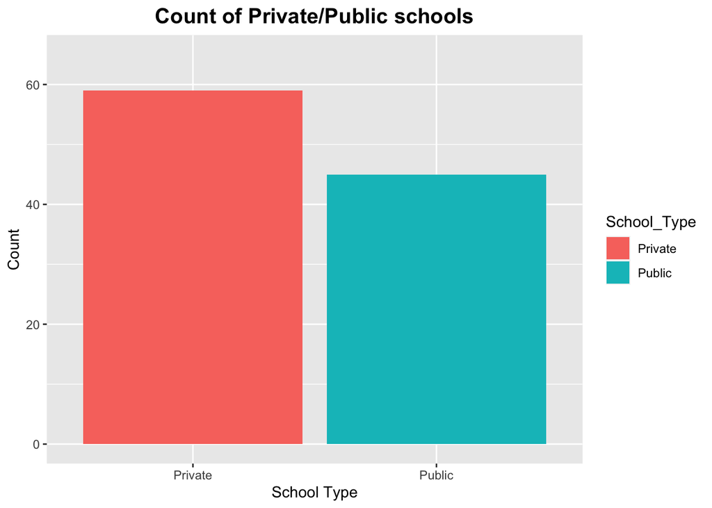

```r
# Create a graph of the number of private and public schools
main_final_table %>% group_by(School_Type) %>%
  summarise(school_type_count = n()) %>%
  ggplot(aes(x=School_Type, y=school_type_count, fill = School_Type)) +
  geom_bar(stat="identity") + ylim(0,65) +
  labs(title="Count of Private/Public schools", x="School Type", y="Count") +
  theme(plot.title = element_text(size = 15, face = "bold", hjust = 0.5))
```

**The plot depicts the number of public and private schools in our data set of top 104 best ranking universities and colleges in the US.There are 59 private schools and 45 public schools in our ranking table, meaning that private schools make a bigger proportion than public schools in this data set.**

#### Analysis 2

Do higher ranking schools (smaller ‘Ranking’ value) have a larger student population than lower ranking ones? Is the correlation different between private and public schools?

```r
#Change data type to numeric
main_final_table$Ranking <- as.numeric(main_final_table$Ranking)
main_final_table$Enrollment <- as.numeric(main_final_table$Enrollment)

#Correlation between ranking and student enrollment
print("Correlation between ranking and student enrollment")
```

```
## [1] "Correlation between ranking and student enrollment"
```

```r
cor(main_final_table$Ranking, main_final_table$Enrollment)
```

```
## [1] 0.2596504
```

```r
#Correlation between ranking and student enrollment, filter by school type
main_final_table %>%
  group_by(School_Type) %>%
  summarise(cor(Ranking, Enrollment))
```

```
## # A tibble: 2 × 2
##   School_Type `cor(Ranking, Enrollment)`
##   <chr>                            <dbl>
## 1 Private                          0.150
## 2 Public                          -0.201
```

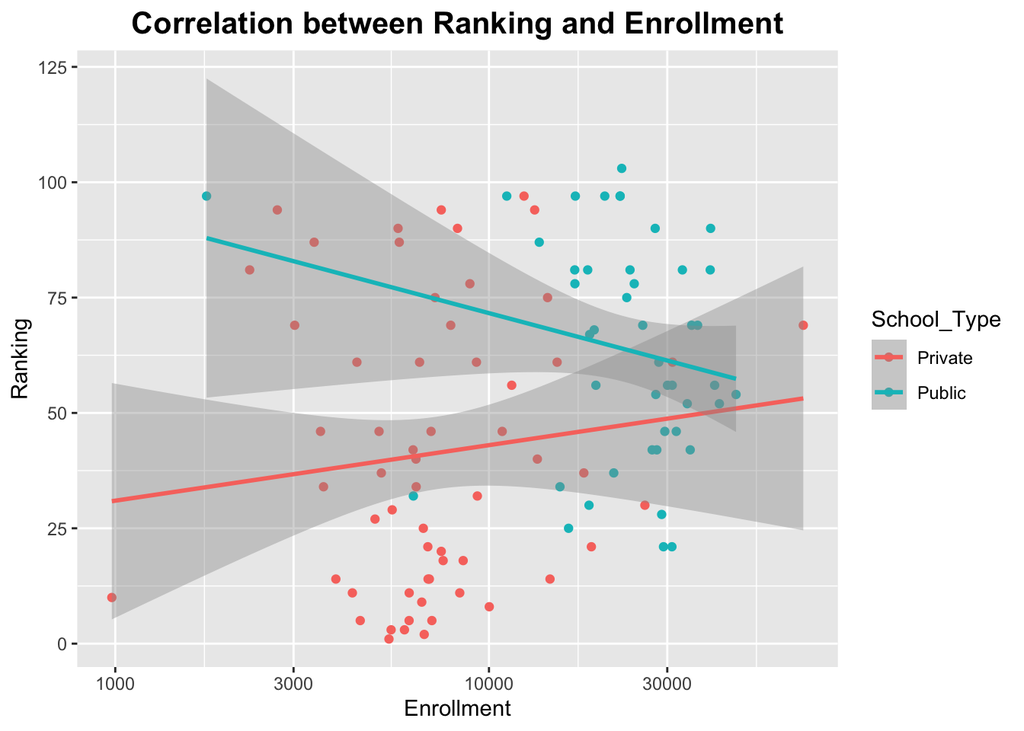

```r
#Graphing a table to depict the correlation, considering the School Type
main_final_table %>%
  ggplot(aes(x = Enrollment, y = Ranking, color = School_Type)) +
  geom_point() + geom_smooth(method = "lm") + scale_x_log10() +
  labs(title="Correlation between Ranking and Enrollment", x="Enrollment", y="Ranking") +
  theme(plot.title = element_text(size = 15, face = "bold", hjust = 0.5))
```

**In general, there is very little correlation between school ranking and student enrollment, only 0.26, meaning higher ranking schools (smaller ‘Ranking’ value) have less student enrollment. A graph is created to see if this relationship changes as we consider the schools’ type. From the graph, we can see that for public schools, the lower ranking schools (higher ‘Ranking’ value) have less enrollment then higher ranking schools (cor = -0.2). However, for private schools, higher ranking schools (smaller ‘Ranking’ value) have less enrollment (cor = 0.15). Based on this information, students can decide whether they want to go to a large or small school, and how that would change depends on whether they prefer private or public schools.**

#### Analysis 3

Do schools with overall higher rankings have a larger population of STEM students?

```r
#Compute the correlation to see relationship between school ranking and student proportion in STEM:
print("Correlation between Ranking and percentage of student in STEM")
```

```
## [1] "Correlation between Ranking and percentage of student in STEM"
```

```r
cor(main_final_table$`STEM_Rate(%)`, main_final_table$Ranking, use = "complete.obs")
```

```
## [1] -0.210229
```

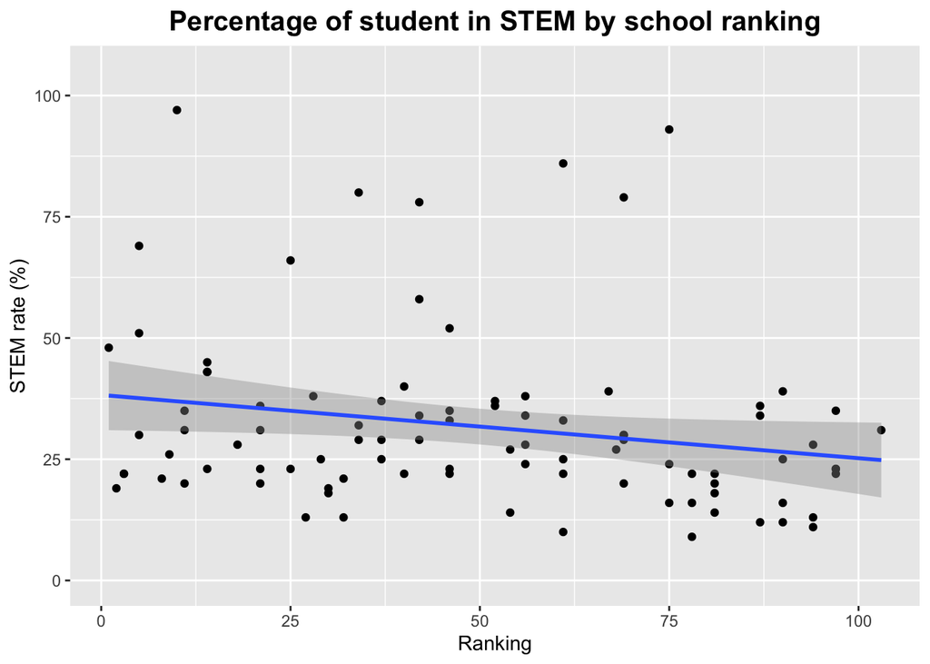

```r
# Create a graph:
main_final_table %>% ggplot(aes(x = Ranking, y= `STEM_Rate(%)`, na.rm=TRUE)) +
  geom_point() + geom_smooth(method = "lm") + ylim(0,105) +
  labs(title="Percentage of student in STEM by school ranking",
       x="Ranking", y= "STEM rate (%)") +
  theme(plot.title = element_text(size = 15, face = "bold", hjust = 0.5))
```

**From the correlation computation, there is little negative correlation between the ranking of a school and the percentage of students in STEM majors, only about -0.21. The same thing can be observed from the graph. This graph and the distribution of the points also indicate that schools have a relatively similar proportion of students in STEM majors, around under 40%. Therefore, students can choose schools in top 100 universities and get into a good STEM environment.**

#### Analysis 4

Do students from higher ranking schools have higher early-career and mid-career salary?

```r
# To see the difference in salary easier, we break the 104 schools into 3 ranking groups and see their salary distribution:
Ranking_breakdown_table <- main_final_table %>%
  mutate(Ranking_breakdown = case_when(Ranking < 37 ~ 'Rank 1-36',
                                       Ranking <69 ~ 'Rank 37-68',
                                       Ranking <105 ~ 'Rank 69-104'))

# Pull out data of min, max, and mean salary of Early-career salary and Mid-career salary:
Ranking_breakdown_table %>%
  group_by(Ranking_breakdown) %>%
  summarise(
    max_start_salary = max(`Early_Career_Pay($)`, na.rm = TRUE),
    min_start_salary = min(`Early_Career_Pay($)`, na.rm = TRUE),
    mean_start_salary = mean(`Early_Career_Pay($)`, na.rm = TRUE),
    max_mid_salary = max(`Mid_Career_pay($)`, na.rm = TRUE),
    min_mid_salary = min(`Mid_Career_pay($)`, na.rm = TRUE),
    mean_mid_salary = mean(`Mid_Career_pay($)`, na.rm = TRUE)
  ) %>% arrange(Ranking_breakdown)
```

```
## # A tibble: 3 × 7
##   Ranking_breakdown max_start_salary min_start…¹ mean_…² max_m…³ min_m…⁴ mean_…⁵
##   <chr>                        <int>       <int>   <dbl>   <int>   <int>   <dbl>
## 1 Rank 1-36                    86300       55000  68458.  156000  100800 126497.
## 2 Rank 37-68                   73600       54400  61200   135500   98600 113044.
## 3 Rank 69-104                  75600       46700  58467.  139900   69800 106733.
## # … with abbreviated variable names ¹min_start_salary, ²mean_start_salary,
## #   ³max_mid_salary, ⁴min_mid_salary, ⁵mean_mid_salary
```

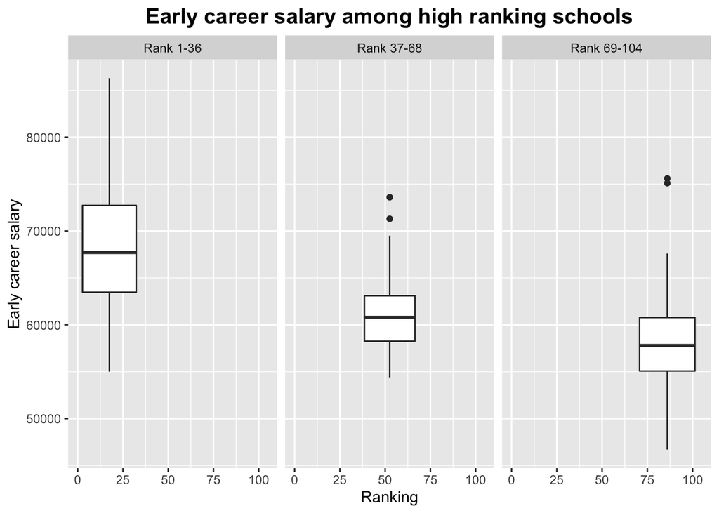

```r
# Create a graph to compare early-career salary of students between 3 groups
Ranking_breakdown_table  %>%
  ggplot(aes(x = Ranking, y = `Early_Career_Pay($)`)) + xlim(0,105) +
  geom_boxplot() + facet_wrap(~Ranking_breakdown)  +
  labs(title="Early career salary among high ranking schools", y="Early career salary") +
  theme(plot.title = element_text(size = 15, face = "bold", hjust = 0.5))
```

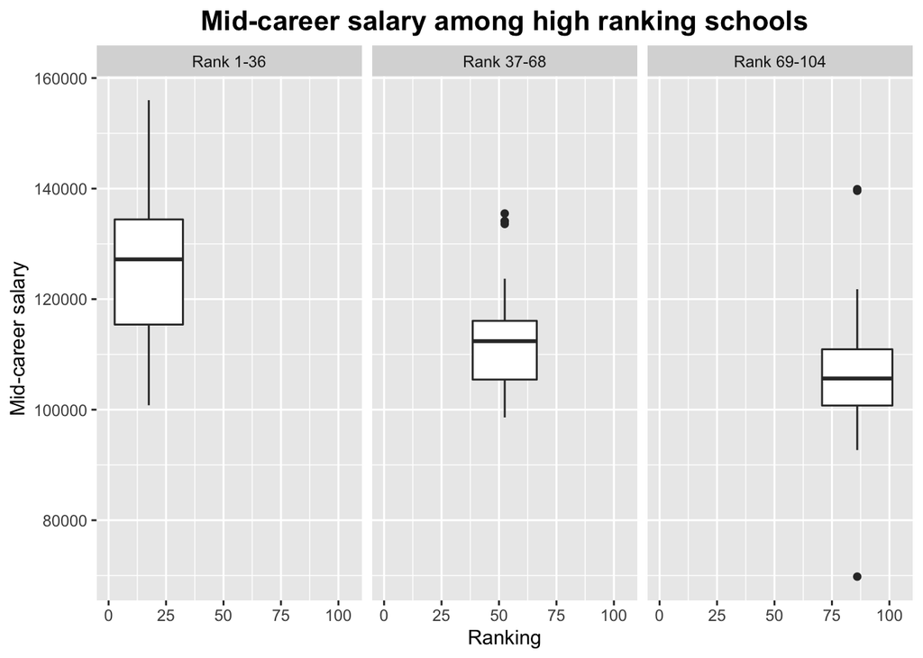

```r
# Create a graph to compare students' salary in their mid-career between 3 groups
Ranking_breakdown_table %>%
  ggplot(aes(x = Ranking, y = `Mid_Career_pay($)`)) +
  geom_boxplot() + facet_wrap(~Ranking_breakdown) + xlim(0,105) +
  labs(title="Mid-career salary among high ranking schools", y="Mid-career salary") +
  theme(plot.title = element_text(size = 15, face = "bold", hjust = 0.5))
```

**We divide all 104 schools into 3 groups by their ranking: Rank 1-36 (36 schools), Rank 37-68 (32 schools) and Rank 69-104 (35 schools), with the smaller ‘Ranking’ values meaning more prestigious and higher ranking schools. We then created box plots to compare the distribution of salaries between the 3 groups by early-career salary and mid-career salary. For the early-career salary graph, it is illustrated that students from higher ranking schools earn more than students in lower ranking schools as the 1st group’s mean, max, and 75th percentile salary values are higher than those of the 2nd and 3rd group. More details on the values can be seen from the table created. A similar trend can be observed as we graph the mid-salary data, the only difference is that the salary range has increased. Obtaining a degree from certain colleges is considered prestigious and may make some graduates more qualified than others. Future students should consider school ranking as a decision factor if their goal is to earn more money after graduation.**

### 3.2 Location & Demographics

#### Analysis 1

What region has the highest number of top ranked schools?

```r
# Count number of schools in each region
main_final_table %>% group_by(Region) %>%summarize(Number = n())
```

```
## # A tibble: 4 × 2
##   Region    Number
##   <chr>      <int>
## 1 Midwest       17
## 2 Northeast     38
## 3 South         32
## 4 West          17
```

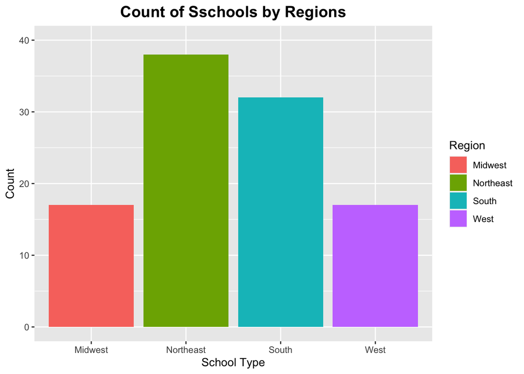

```r
# Create a graph to depict this distribution
ggplot(main_final_table,aes(Region,fill=Region)) + geom_bar() + ylim(0,40) +
  labs(title="Count of Sschools by Regions", x="School Type", y="Count") +
  theme(plot.title = element_text(size = 15, face = "bold", hjust = 0.5))
```

**Based on the observation, the Northeast region has the most top-100 universities. This makes sense because the Northeast region is famous for historically prestigious schools, including all Ivy League schools. Following in the 2nd place is the South region as this is a broad area. Lastly, the Midwest and west have an equal amount of top-100 schools.**

#### Analysis 2

Which regions tend to have more diverse student bodies?

```r
# Compute the average female participation rate, group schools by region
main_final_table %>% group_by(Region) %>%summarize(Average_Female_participation_rate = mean(`Female_Ratio(%)`)) %>% knitr::kable()
```

| Region | Average_Female_participation_rate |
| --- | --- |
| Midwest | 49.76471 |
| Northeast | 48.44737 |
| South | 51.68750 |
| West | 49.00000 |

**Female participation rate is another very important index to consider when looking at the diversity of a campus. In four regions, the South region has the highest Female participation rate on average of top-100 schools and the Northeast region has the least, but the differences are not big. Therefore, if diversity and inclusion are things students aim for, they should choose schools in the South region rather than Northeast region.**

### 3.3 Cost

#### Analysis 1

Affordability of high ranking schools

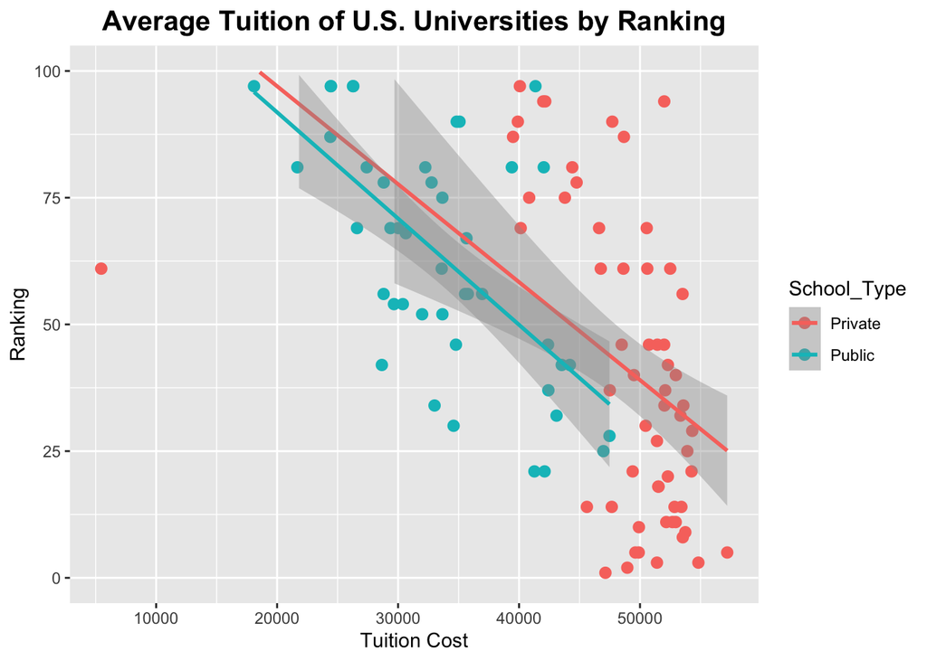

```r
# Change data type to numeric
main_final_table$`Tuition($)` <- as.numeric(main_final_table$`Tuition($)`)

# Create a graph to see the relationship between tuition and the school ranking
main_final_table %>%
  ggplot(aes(x = `Tuition($)`, y = Ranking, color = School_Type)) +
  geom_point(size = 2.5) +
  geom_smooth(method="lm") +
  xlab("Tuition Cost") +
  ggtitle("Average Tuition of U.S. Universities by Ranking") +
  theme_gray() +
  theme(plot.title = element_text(size = 15, face = "bold", hjust = 0.5)) +
  ylim(0, 100)
```

**This scatter plot visualizes the tuition costs of top ranked U.S. universities plotted against each ranking. Since we interpret the smallest number rankings as being the “highest ranking” schools, from this data we can conclude that the higher a university is ranked, most likely the more expensive it will be. Higher tuition rates coincide with highly ranked programs that have more funding to provide quality education, independent research, and extra-curriculars. By coloring by Public/Private, we can also conclude that schools with the highest ranking are also typically private universities, hence the expensive tuition. The one private school outlier is BYU, where students with certain religious affiliations have reduced tuition rates.**

#### Analysis 2

Average cost of all schools

```r
# Calculate average cost of all 100 schools
mean(main_final_table$`Tuition($)`)
```

```
## [1] 42261.64
```

```r
#name, tuition, and ranking of the top 10 most expensive schools
max_cost <- main_final_table %>% slice_max(`Tuition($)`, n=10)

#name, tuition, and ranking of the top 10 least expensive schools
min_cost <- main_final_table %>% slice_min(`Tuition($)`, n=10)

max_cost
```

```
## # A tibble: 10 × 12
##    Ranking School…¹ Tuiti…² Schoo…³ Enrol…⁴ State Region Early…⁵ Mid_C…⁶ STEM_…⁷
##      <dbl> <chr>      <dbl> <chr>     <dbl> <chr> <chr>    <int>   <int>   <int>
##  1       5 COLUMBI…   57208 Private    6113 NY    North…   71400  126800      30
##  2       3 UNIVERS…   54825 Private    5941 IL    Midwe…   64000  114200      22
##  3      29 TUFTS U…   54318 Private    5508 MA    North…   65200  118100      25
##  4      21 UNIVERS…   54259 Private   18794 CA    West     64500  120600      23
##  5      25 CARNEGI…   53910 Private    6673 PA    North…   75900  136100      66
##  6       9 DUKE UN…   53744 Private    6609 NC    South    71100  132100      26
##  7      34 BRANDEI…   53582 Private    3608 MA    North…   60600  113200      29
##  8       8 UNIVERS…   53534 Private   10019 PA    North…   72800  133900      21
##  9      56 GEORGE …   53518 Private   11504 DC    South    66000  133600      NA
## 10      14 BROWN U…   53419 Private    6926 RI    North…   68200  127600      43
## # … with 2 more variables: `Male_Ratio(%)` <dbl>, `Female_Ratio(%)` <dbl>, and
## #   abbreviated variable names ¹School_Name, ²`Tuition($)`, ³School_Type,
## #   ⁴Enrollment, ⁵`Early_Career_Pay($)`, ⁶`Mid_Career_pay($)`, ⁷`STEM_Rate(%)`
```

```r
min_cost
```

```
## # A tibble: 10 × 12
##    Ranking School…¹ Tuiti…² Schoo…³ Enrol…⁴ State Region Early…⁵ Mid_C…⁶ STEM_…⁷
##      <dbl> <chr>      <dbl> <chr>     <dbl> <chr> <chr>    <int>   <int>   <int>
##  1      61 BRIGHAM…    5460 Private   30979 UT    West     59200  108000      25
##  2      97 SUNY CO…   18090 Public     1755 NY    North…   55400   95500      NA
##  3      81 FLORIDA…   21673 Public    32929 FL    South    50800   92700      18
##  4      87 BINGHAM…   24403 Public    13632 NY    North…   61300  109600      34
##  5      97 UNIVERS…   24443 Public    22436 OK    South    54400  100600      23
##  6      97 UNIVERS…   24443 Public    22436 OK    South    59000  105300      23
##  7      97 UNIVERS…   26270 Public    20411 NY    North…   46700   69800      NA
##  8      97 STONY B…   26297 Public    17026 NY    North…   59200  107800      35
##  9      69 UNIVERS…   26603 Public    34871 MN    Midwe…   57200  104000      30
## 10      81 NORTH C…   27406 Public    23847 NC    South    62200  114200      NA
## # … with 2 more variables: `Male_Ratio(%)` <dbl>, `Female_Ratio(%)` <dbl>, and
## #   abbreviated variable names ¹School_Name, ²`Tuition($)`, ³School_Type,
## #   ⁴Enrollment, ⁵`Early_Career_Pay($)`, ⁶`Mid_Career_pay($)`, ⁷`STEM_Rate(%)`
```

**For the top ranked 100 universities in the U.S., the average tuition for all of them is $42,261.64 per year. This average is on the higher end, and closer to the maximum tuition of $57,208 per year at Columbia University. Typically, we assume that private universities tend to have higher tuition which is reinforced by our table because the top ten most expensive schools are all private. Besides two, all of the most expensive schools also have a ranking less than 30 (#1 being the best). However, the top ten least expensive schools all have a ranking of 60 or more, but with a cheaper tuition of about $30k. Considering that these are the top ranked 100 schools in the country, all are respectable and have good programs. Future students would have to consider other factors like affordability, the types of majors they want to pursue, and campus culture to make a final decision.**

#### Analysis 3

Cost of tuition per region

```r
# Calculate the average tuition cost by region
main_final_table %>%
  group_by(Region) %>%
  summarise(avg_cost_per_region = mean(`Tuition($)`))
```

```
## # A tibble: 4 × 2
##   Region    avg_cost_per_region
##   <chr>                   <dbl>
## 1 Midwest                39721.
## 2 Northeast              45195.
## 3 South                  40172.
## 4 West                   42179.
```

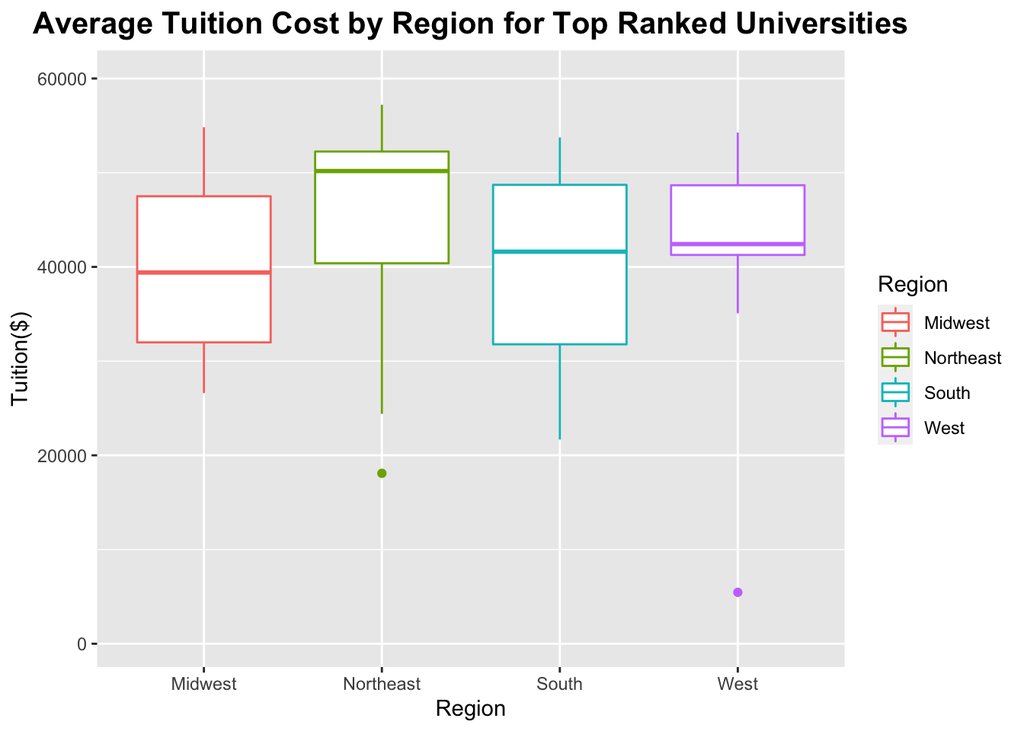

```r
# Graph the findings
ggplot(main_final_table, aes(x = Region, y = `Tuition($)`, color = Region)) +
  geom_boxplot() +
  ggtitle("Average Tuition Cost by Region for Top Ranked Universities") +
  theme(plot.title = element_text(size = 15, face = "bold", hjust = 0.5)) + ylim(500,60000)
```

```r
  ylab("Tuition Cost")
```

```
## $y
## [1] "Tuition Cost"
##
## attr(,"class")
## [1] "labels"
```

**After computing summary statistics, the region with the most expensive tuition on average is the Northeast at $45,194.89. The region with the least expensive top ranked schools is the Midwest at $39,720.59. This plot can be used by future students in determining which areas of the U.S. tend to have the most expensive schools. If affordability is a concern, a student may want to consider attending a university in the Midwest where tuition costs are lower on average.**

# 4. Concluding Statement

**To conclude, our goal was to create a baseline analysis that can help future college students understand the various factors that influence where they may want to attend college. Since these colleges are the top 100 best in the U.S, the quality of education will overall be good. To make sure students pick the best fitting university for themselves, individuals may want to analyze other variables like campus culture. Incoming freshmen can hopefully use this information to reduce some of the stress that comes with picking a college. Each member within our group contributed equally to the project. Allison wrote the introduction and conclusion paragraphs as well as computed the Cost analyses. Thao organized the information within the markdown file and computed the Academic Quality analyses. Shuhan wrangled data to form our final table and computed the Location analyses. Each member helped organize the direction of our project and finding data sources.**